# Noncompartmental Analysis

## Introduction

Non-compartmental analysis (NCA) is a simple and quick method for evaluating the exposure of a drug. It allows you to evaluate things like linearity and in vivo exposure. To illustrate this consider an antibody given in a subcutaneous injection. The actual profile a patient might experience is given in the solid black line. But we don’t yet have the ability to sample in a continuous fashion. What we might observer is given by the blue points.

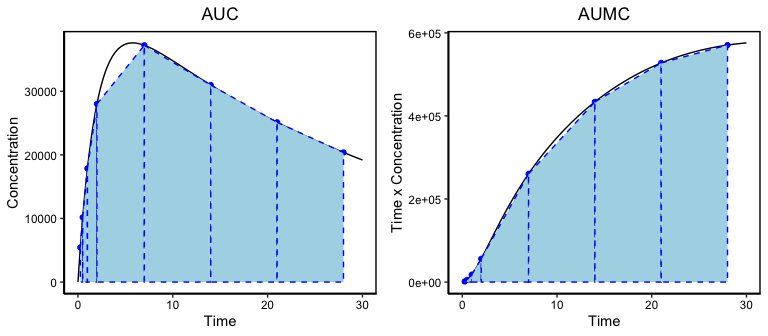

Generally NCA will determine the following directly from the data:

- `Cmax` - Maximum observed concentration (units=concentration)
- `Tmax` - The time where the maximum concentration was observed (units=time)
- `AUC` - The area under the curve ($units=time \times concentration$)
- `AUMC` - The area under the first moment curve ($units=time^2 \times concentration$)

These properties are all based on observational data. So the `Cmax` and `Tmax` will most certainly not be at the actual maximum concentration but as long as we sample judiciously it will give us a good approximation. Similarly, the calculated `AUC` and `AUMC` will be different than the actual values. To calculate the areas you need to dig back into your calculus text books to the trapezoid method. Basically each sampling interval is a trapezoid and the area of each is calculated and added up for all of the `n` samples:

$$AUC = \int_0^{t_f} Cdt
\approx \sum_{i=1}^{n-1}{\frac{C_i+C_{i+1}}{2}\times
(t_{i+1}-t_{i})}, \ \ \ \ \
AUMC = \int_0^{t_f} t\times Cdt
\approx \sum_{i=1}^{n-1}{\frac{t_iC_i+t_{i+1}C_{i+1}}{2}\times
(t_{i+1}-t_{i})}$$

This can be done in Excel pretty easily. Depending on the data and the analysis other properties can be calculated. For example we can calculate the clearance, steady-state volume of distribution and terminal half-life:

- Clearance: $CL = \frac{Dose}{AUC}$
- Mean residence time: $MRT = \frac{AUMC}{AUC}$
- Steady state volume of distribution: $V_{ss} = MRT \times CL$
- Half-life: Terminal slope of the natural log of the data

Properties like AUC and AUMC can also be be calculated using extrapolation from the last time point to infinity to account for data beyond the observations at hand. The subsequent values of clearance, volumes of distribution, etc can also change with extrapolation.

There is a lot of nuance associated with these calculations, and it is good to rely on software that focuses on this type of analysis. The [`PKNCA`](https://github.com/billdenney/pknca) package has been developed with this in mind. Ubiquity provides a set of functions to automate NCA and reporting for preclinical data. These functions act as a wrapper for the `PKNCA` package which does most of the heavy lifting. Only a small subset of the `PKNCA` functionality is used here. If more extensive analysis is necessary then `PKNCA` can be used directly.

This vignette contains a series of examples on how to perform NCA in ubiquity. To make a copy of these scripts and other supporting files in the current working directory run the following:

```r
library(ubiquity)
fr = workshop_fetch(section="NCA", overwrite=TRUE)
```

This creates several files in the working directory. First are data sets:

- `pk_all_sd.csv` - PK data for multiple subjects dosed either IV or SC at different levels
- `pk_all_md.csv` - Multiple dose data with intensive sampling on the first and last dose
- `pk_sparse_sd.csv` - Single dose data with sparse sampling

Next the following scripts demonstrate how to perform NCA:

- `analysis_nca_sd.R` - Single dose data for individuals
- `analysis_nca_md.R` - Multiple dose data for individuals
- `analysis_nca_sparse.R`- Average NCA when analyzing sparsely sampled data

## Quick Template for Running NCA

You should read the rest of the vignette below to understand the required data format and how the functions work. But if you are returning to this and you just want a template for running NCA you can use the following:

```r
library(ubiquity)
cfg = build_system()
fr = system_fetch_template(cfg, template = "NCA")
```

This will create the file `analysis_nca.R` in the current working directory. You can just uncomment/edit that script to get started.

## Single Dose Data

This example follows the script `analysis_nca_sd.R`, and uses the dataset `pk_all_sd.csv`.

### Expected Format of Data

First we build the system and load the dataset.

```r
cfg = build_system(system_file="system.txt")
cfg = system_load_data(cfg, dsname     = "PKDATA",
                            data_file  = "pk_all_sd.csv")
```

The NCA functions in ubiquity expect data to have a certain format. There are columns that are required, those that are optional or depend on the kind of analysis being performed and other columns can also be present. In this context consider the following dataset:

[interactive table not shown]

The required columns and their names in this dataset provided in parenthesis are:

- `ID` - Unique subject identifier (`ID`)
- `TIME` - Time since the first dose (`TIME_HR`)
- `NTIME` - Nominal time since the last or most recent dose (since we are dealing with single dose data this is also `TIME_HR`)
- `CONC` - Observed concentration for this record (`C_ng_ml` in ng/ml)
- `DOSE` - Dose given (`DOSE` in mg)
- `ROUTE` - Route of administration (`ROUTE`); can be either: `iv bolus`, `iv infusion` or `extra-vascular`

Optional columns include:

- `DOSENUM` - When analyzing multiple dose data (example below), this column will be used to associate records with doses
- `BACKEXTRAP` - Back-extrapolation of IV data can be done generally for the entire dataset or this column can be used to specify the number of points to use on an individual basis
- `SPARSEGROUP` - Grouping for sparse sampling data where you want to average data at each time point

### NCA and Outputs

Next we perform the NCA using `system_nca_run`:

```r
cfg = system_nca_run(cfg,  dsname        = "PKDATA",
                           dscale        = 1e6,
                           analysis_name = "pk_single_dose",
                           extrap_C0     = FALSE,
                           dsmap         = list(TIME    = "TIME_HR",
                                                NTIME   = "TIME_HR",
                                                CONC    = "C_ng_ml",
                                                DOSE    = "DOSE",
                                                ROUTE   = "ROUTE",
                                                ID      = "ID"),
                           NCA_options   = list(max.aucinf.pext  = 10) )
```

We link the analysis to the dataset by specifying the dataset name (`dsname`) used when we load the dataset. Data can be filtered either before it’s loaded or by using the optional `dsfilter` input (not used here). The dosing in the dataset is in mg (i.e. 30 mg dose), but the mass units of the concentration values are in ng (i.e. ng/ml). The `dscale` input converts the mass units in the dose to the mass units in the observed concentration. The `analysis_name` [^1] is used both to refer to this analysis in the reporting function as well as in the files generated by the analysis. By default the initial concentration (nominal time zero) will be back-extrapolated but can be disabled by setting `extrap_C0` to FALSE. Next we map the columns in the dataset to names used by the analysis (`dsmap`). Note that both the actual time (`TIME`) and nominal time (`NTIME`) both use the same column in the dataset (`TIME_HR`). Lastly, the `NCA_options` can be used to specify the analysis options used by PKNCA. In the example above the maximum percent of AUCinf extrapolation is being specified at 10%. This will only change this option and the remaining defaults from PKCNA will be used. Either omit this argument or set it to NULL to use all of the PKNCA defaults.

Running this function will produce the following files:

- `output/pk_single_dose-nca_summary-pknca.csv` Summary level output from the analysis (see table below)
- `output/pk_single_dose-nca_data.RData` R objects used for downstream reporting
- `output/pk_single_dose-pknca_raw.csv` Raw output from PKNCA

It may be useful to carry forward the values of certain columns in the PK dataset into the output. To do this you can use the `dsinc` argument and provide a list of columns in your input dataset to be appended to the summary table. You can access the summary table using the function `system_fetch_nca` and the `analysis_name`:

```r
NCA_results = system_fetch_nca(cfg, analysis_name = "pk_single_dose")
```

[interactive table not shown]

To get an explanation of the columns in the NCA output you can use the `system_fetch_nca_columns` function passing the NCA analysis name to the function. The list output contains a data frame `NCA_col_summary` with the outputs and a description of their meaning:

```r
nca_cols = system_fetch_nca_columns(cfg, "pk_single_dose")
rhandsontable(nca_cols[["NCA_col_summary"]],  width="100%", height=200)
```

[interactive table not shown]

### Automated Reporting

#### PowerPoint

Once the NCA has been run, the results can be appended to an open PowerPoint report. Here we initialize an empty report then use the function `system_rpt_nca()` and the analysis name assigned to the analysis above (`pk_single_dose`) to attach those results. Then we can write the file:

```r
cfg = system_rpt_read_template(cfg, template="PowerPoint")
cfg = system_rpt_add_slide(cfg,
  template = "title_slide",
  elements = list( title= list(content = "NCA Single Dose PK", type    = "text")))
cfg = system_rpt_nca(cfg=cfg, analysis_name="pk_single_dose")
system_rpt_save_report(cfg=cfg, output_file=file.path("output","pk_single_dose-report.pptx"))
```

For each dose a summary slide will be produced and a full timecourse will be created showing all of the data for that subject/group in the dataset:

- Actual data in gray
- Data used for NCA in green
- Initial extrapolated concentrations in orange (solid)
- Points used for extrapolating “iv bolus” data are shown in orange open circles

Below shows the slides generated for an individual subject and the first set of summary slides for the analysis. Notice that because `extrap_C0` was set to `FALSE` C0 was not calculated (`-1`). Because this individual received a SC dose the estimate for `Vp` is also not calculated (`-1`). Also note that the data for this individual did not allow for extrapolation of AUC to infinity (`NA`). As a result the parameters that depend this value also resulted in (`NA`). The timecourse figure shows the data in the dataset (gray closed symbols, solid line) and the data used for NCA (green open symbols, dashed line). This way you can visually confirm at the subject level what data was used.

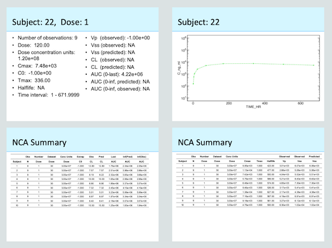

Reporting for single dose NCA

#### Word

Similarly, a Word report can be generated by appending the results to an already initialized Word report. This is done by setting the `template` to `"Word"` when calling `system_rpt_read_template()`. This will attach the same content to the report as with PowerPoint report above.

```r
cfg = system_rpt_read_template(cfg, template="Word")
cfg = system_rpt_nca(cfg=cfg, analysis_name="pk_single_dose")
system_rpt_save_report(cfg=cfg, output_file=file.path("output","pk_single_dose-report.docx"))
```

For more information on integrated report generation see the `Reporting` vignette.

### Summarizing Data

The automated reporting is intended to generate results quickly in an easily digestible way (Word and PowerPoint). But you may decided you need more control over what is being presented. The function `system_fetch_nca()` mentioned above will give you access to all of the NCA output. If you want to filter, select columns and summarize results the function `system_nca_summary()` can be used. The first argument (`analysis_name`) indicates the NCA analysis you want to summarize. The parameters being summarized and their order in the table is specified by `params_include`. By default internal headers will be used, but you can overwrite or alter those defaults with optional `params_header` input. Here `cmax` is being overwritten with the internally predefined label (`"<label>"`) on the first header row, and the units (`"(ng/ml)"`) on the second header row. In this table we only want to present the 30 mg dose. The `ds_wrangle` option will filter down the results to just that dosing cohort. It may be desirable to further summarize results. The `summary_stats` option is a list of values to summarize and the columns where those summaries should appear. Each name in that list will create a row at the bottom of the column. You can specify the summary labels with `summary_labels` and indicate which column to contain those labels with `summary_location`.

```r
nca_table = system_nca_summary(cfg,
       analysis_name    = "pk_single_dose",
       params_include   = c( "ID", "cmax", "tmax", "half.life", "auclast"),
       params_header    = list(cmax = c( "<label>", "(ng/ml)")),
       ds_wrangle       = "NCA_sum = NCA_sum %>% dplyr::filter(Dose == 30)",
       summary_stats    = list("<MEAN> (<STD>)" = c("auclast", "half.life"),
                               "<MEDIAN>"       = c("tmax")),
       summary_labels   = list(MEAN             = "Mean",
                               STD              = "Std Dev",
                               N                = "N obs",
                               MEDIAN           = "Median",
                               SE               = "Std Err."),
       summary_location = "ID")

nca_table[["vignette"]] = set_table_properties(nca_table$nca_summary_ft,layout = "autofit")
```

The output of `system_nca_summary()` is a list with elements that are designed to facilitate reporting. The unformatted tabular information is provided in a dataframe (`nca_summary`) and this can be saved as text for archival purposes. Flextable output (`nca_summary_ft`) is also provided. This can be further customized if needed and eventually be used in Word or PowerPoint (see below). If you want to create your own output from this you can use the `components` field.

| ID | Cmax (ng/ml) | Tmax | Half-life | AUC last |
| --- | --- | --- | --- | --- |
| 1 | 9,950 | 1 | 423 | 1,760,000 |
| 2 | 11,300 | 1 | 477 | 2,510,000 |
| 3 | 7,420 | 1 | 500 | 2,320,000 |
| 4 | 5,760 | 1 | 589 | 1,650,000 |
| 5 | 6,460 | 1 | 574 | 1,890,000 |
| 6 | 9,460 | 1 | 526 | 2,450,000 |
| 7 | 13,800 | 1 | 627 | 3,230,000 |
| 8 | 7,160 | 1 | 567 | 1,970,000 |
| 9 | 9,180 | 1 | 561 | 2,180,000 |
| 10 | 4,760 | 1 | 500 | 1,250,000 |
| 11 | 4,670 | 1 | 599 | 1,630,000 |
| 12 | 12,100 | 1 | 546 | 2,620,000 |
| 13 | 6,380 | 1 | 581 | 2,010,000 |
| 14 | 5,130 | 1 | 549 | 1,620,000 |
| 15 | 4,910 | 1 | 751 | 1,890,000 |
| 16 | 7,580 | 1 | 619 | 1,640,000 |
| 17 | 10,200 | 1 | 507 | 2,500,000 |
| 18 | 10,600 | 1 | 639 | 2,900,000 |
| Mean (Std Dev) |  |  | 563 (73.1) | 2110000 (517000) |
| Median |  | 1 |  |  |

## Multiple Dose Data

This example follows the script `analysis_nca_md.R`, and uses the dataset `pk_all_md.csv`. If we rebuild the system and load the multiple dose dataset we can see that the dataset looks almost identical to the single dose data set. The primary difference is that there are two extra columns: `NTIME_HR` and `EXTRAP`. The first column (`NTIME_HR`) contains the time since the last dose. The `EXTRAP` column is optional and allows the user to specify the number of points to back extrapolate C0 for `iv bolus` dosing. This will have no effect unless it is specified in the `dsmap` below. If you scroll through the data you can see that there is intensive sampling for `DOSENUM` 1 and 6. But for doses 2-5 there are only three samples per interval. These latter dose intervals (2-5) will be ignored with the default value of `NCA_min` (4) which defines the minimum number of samples required for analysis.

```r
cfg = build_system(system_file="system.txt")
cfg = system_load_data(cfg, dsname     = "PKDATA",
                            data_file  = "pk_all_md.csv")
```

[interactive table not shown]

Next we perform the NCA and reporting as before. The only difference here is that we’ve removed the `extrap_C0` option. The default value is `TRUE` so back-extrapolation will occur. For IV dosing this is log-linear extrapolation to a nominal time of zero. For SC dosing this will be 0 for the first dose and the last observation from the last dosing interval for subsequent dosing.

```r
cfg = system_nca_run(cfg, dsname        = "PKDATA",
                          dscale        = 1e6,
                          analysis_name = "pk_multiple_dose",
                          dsmap         = list(TIME    = "TIME_HR",
                                               NTIME   = "NTIME_HR",
                                               CONC    = "C_ng_ml",
                                               DOSE    = "DOSE",
                                               ROUTE   = "ROUTE",
                                               ID      = "ID",
                                               DOSENUM = "DOSENUM",
                                               EXTRAP  = "EXTRAP"))
cfg = system_rpt_read_template(cfg, template="PowerPoint")
cfg = system_rpt_nca(cfg=cfg, analysis_name="pk_multiple_dose")
system_rpt_save_report(cfg=cfg, output_file=file.path("output","pk_multiple_dose-report.pptx"))
```

The same files are generated with the `pk_multiple_dose` prefix in the out `output` folder. The summary can be seen here:

[interactive table not shown]

Below you can see the report slides for two subjects. The first subject was dosed IV. Again the gray markers/solid line show the full timecourse for that subject from the dataset. The data used for NCA (dose 1 and 6) is shown in green. The solid orange marker shows the extrapolated C0. If you look closely the open orange markers show the data points used for extrapolation connected with an orange dashed line. The second subject was given SC doses. For the first dose the extrapolated C0 was zero. This can be seen by the green dashed line extending down to zero. The C0 for dose 6 is simply the last observation carried forward as shown by the solid orange marker.

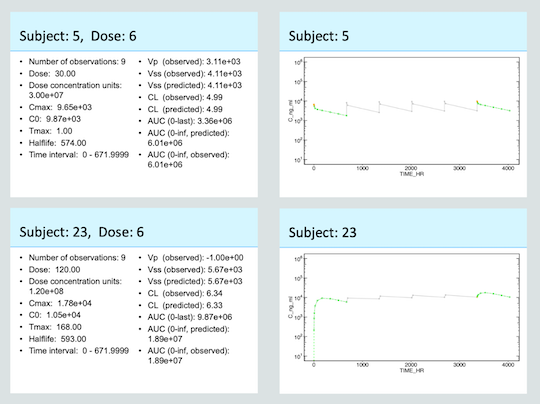

Reporting for multiple dose NCA

## Sparse Sampling

```r
cfg = build_system(system_file="system.txt")
cfg = system_load_data(cfg, dsname     = "PKDATA",
                            data_file  = "pk_sparse_sd.csv")
```

[interactive table not shown]

When we run the NCA we need to tell the function that we want to perform a sparse analysis. This is done by setting the `sparse` input to `TRUE`. We also need to provide information on how to group cohorts. This is done by providing a `SPARSEGROUP` option in the `dsmap`. In this case we can just use the `DOSE` column, however a different column could have been used.

```r
cfg = system_nca_run(cfg, dsname        = "PKDATA",
                          dscale        = 1e6,
                          analysis_name = "pk_sparse",
                          sparse        = TRUE,
                          dsmap         = list(TIME        = "TIME_HR",
                                               NTIME       = "TIME_HR",
                                               CONC        = "C_ng_ml",
                                               DOSE        = "DOSE",
                                               ROUTE       = "ROUTE",
                                               ID          = "ID",
                                               SPARSEGROUP = "DOSE"))
cfg = system_rpt_read_template(cfg, template="PowerPoint")
cfg = system_rpt_add_slide(cfg,
  template = "title_slide",
  elements = list( title= list(content = "NCA of Sparsely Sampled PK", type    = "text")))
cfg = system_rpt_nca(cfg=cfg, analysis_name="pk_sparse")
system_rpt_save_report(cfg=cfg, output_file=file.path("output","pk_sparse-report.pptx"))
```

Analysis of sparse data will calculate an average concentration at each time point and use those average values for NCA. The same files are generated from the analysis. You can see the summary here:

[interactive table not shown]

To confirm what was done and identify any outliers that may be causing problems, you can use the report output. Again the gray markers show the data, the green dashed line will show the value used for NCA, and the orange will show the C0 estimate.

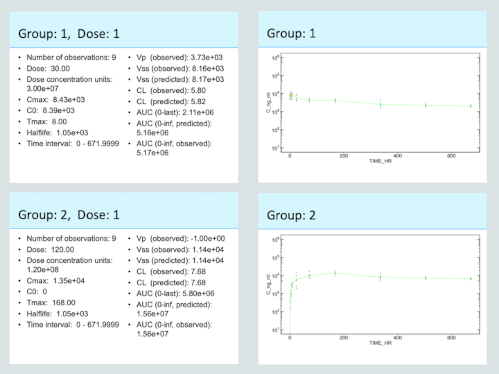

Reporting for sparse sampling NCA

[^1]: analysis names must start with a letter and containing only letters, numbers, and _